# Lesson 3

### What to Do First?

Notes:

### Pseudo-Facebook User Data

Notes:

```r
getwd()
```

```
## [1] "C:/Users/haoli/OneDrive/Documents/GitHub/DataAnalysiswithRUdacity"
```

```r
setwd('C:/Users/haoli/OneDrive/Documents/GitHub/DataAnalysiswithRUdacity/lesson3')
list.files()
```

```
## [1] "lesson3_student.rmd" "pseudo_facebook.tsv"
```

```r
# *.tsv is tab separated values, so the seperator is set to tabs \t.
pf <- read.csv('pseudo_facebook.tsv',sep = '\t')
# read.delim's default separator is \t.
pf2 <- read.delim('pseudo_facebook.tsv')
names(pf)
```

```
##  [1] "userid"                "age"
##  [3] "dob_day"               "dob_year"
##  [5] "dob_month"             "gender"
##  [7] "tenure"                "friend_count"
##  [9] "friendships_initiated" "likes"
## [11] "likes_received"        "mobile_likes"
## [13] "mobile_likes_received" "www_likes"
## [15] "www_likes_received"
```

### Histogram of Users’ Birthdays

Notes:

```r
# install.packages('ggplot2')
library(ggplot2)

names(pf)
```

```
##  [1] "userid"                "age"
##  [3] "dob_day"               "dob_year"
##  [5] "dob_month"             "gender"
##  [7] "tenure"                "friend_count"
##  [9] "friendships_initiated" "likes"
## [11] "likes_received"        "mobile_likes"
## [13] "mobile_likes_received" "www_likes"
## [15] "www_likes_received"
```

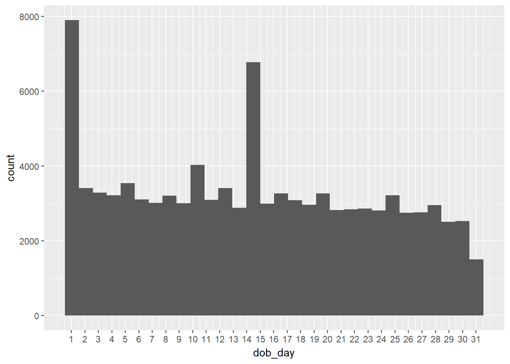

```r
# '+' is used to add additional condition for the bin size
qplot(x = dob_day, data = pf) +
  scale_x_continuous(breaks=1:31)
```

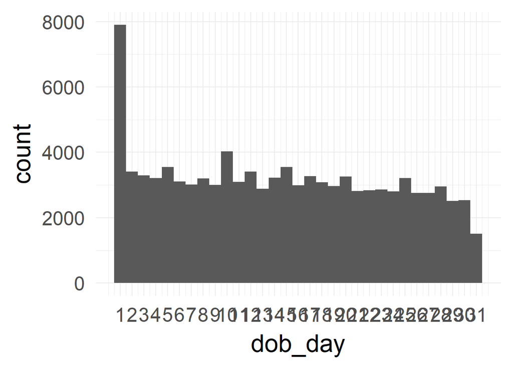

```r
# install.packages('ggthemes', dependencies = TRUE)
library(ggthemes)
theme_set(theme_minimal(24))
ggplot(aes(x = dob_day), data = pf) +
  geom_histogram(binwidth = 1) +
  scale_x_continuous(breaks = 1:31)
```

#### What are some things that you notice about this histogram?

Response: This first day of each month has an extremely high value compared to other dates, which was not normal. The 31st day of the month has a lower value compared to other dates, which corresponded to that not all months have 31 days.

### Moira’s Investigation

Notes:

### Estimating Your Audience Size

Notes:

#### Think about a time when you posted a specific message or shared a photo on Facebook. What was it?

Response: I posted pictures of diving, fishing, and snorkeling while I was in Maldives.

#### How many of your friends do you think saw that post?

Response: 80.

#### Think about what percent of your friends on Facebook see any posts or comments that you make in a month. What percent do you think that is?

Response: 35

### Perceived Audience Size

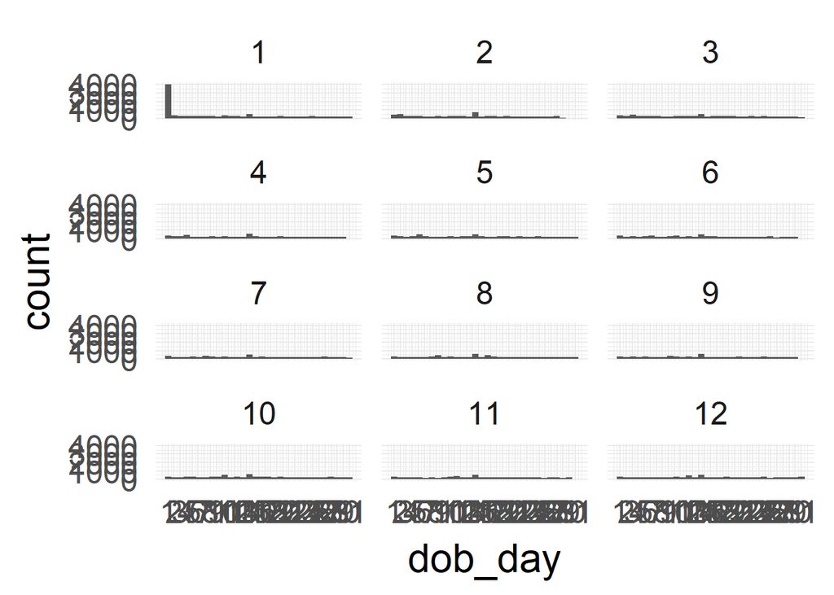

```r
qplot(x = dob_day, data = pf) +
  scale_x_continuous(breaks=1:31) +
  facet_wrap(~dob_month,ncol = 3)
```

#### Letâs take another look at our plot. What stands out to you here?

Response: There were so many people born on the 1st of January. That might be because that the default value is Jan 1st, and many people chose to use it to protect their privacy.

### Be Skeptical - Outliers and Anomalies

Notes: Outliers and anomalies sometimes reporesent bad data, or the limitation of your data.

### Friend Count

Notes:

#### What code would you enter to create a histogram of friend counts?

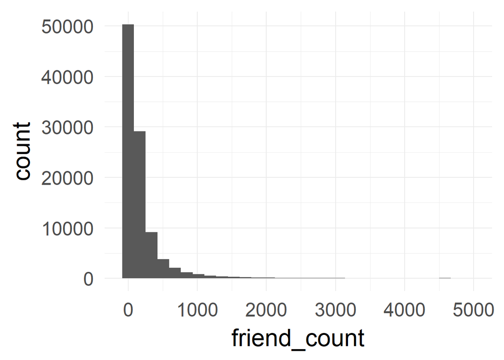

```r
qplot(data = pf, x = friend_count)
```

#### How is this plot similar to Moira’s first plot?

Response: There are outliers with extreme values. Long-tail data. ***

### Limiting the Axes

Notes:

```r
# All three plot are equivalent
qplot(data = pf, x = friend_count, xlim = c(0,1000))
qplot(data = pf, x = friend_count) +
  scale_x_continuous(limits = c(0,1000))
ggplot(aes(x = friend_count), data = pf) +
  geom_histogram() +
  scale_x_continuous(limits = c(0, 1000))
```

[output not shown]

### Exploring with Bin Width

Notes:

### Adjusting the Bin Width

Notes: Most people guess the audience size at 20, 50, and 100, not numbers in between.

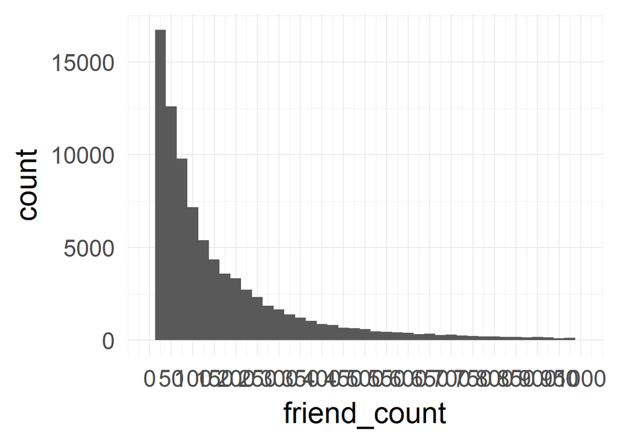

```r
qplot(data = pf, x = friend_count, binwidth = 25) +
  scale_x_continuous(limits = c(0,1000), breaks = seq(0, 1000, 50))
```

### Faceting Friend Count

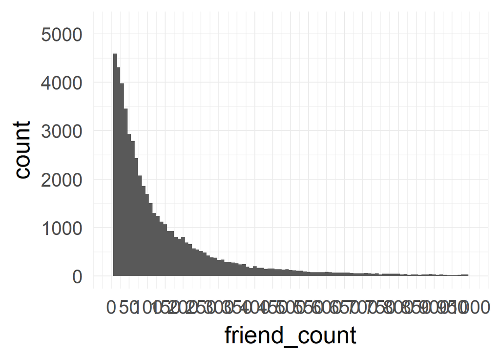

```r
# What code would you add to create a facet the histogram by gender?
# Add it to the code below.
qplot(x = friend_count, data = pf[pf$gender == "male",], binwidth = 10) +
  scale_x_continuous(limits = c(0, 1000),
                     breaks = seq(0, 1000, 50))
```

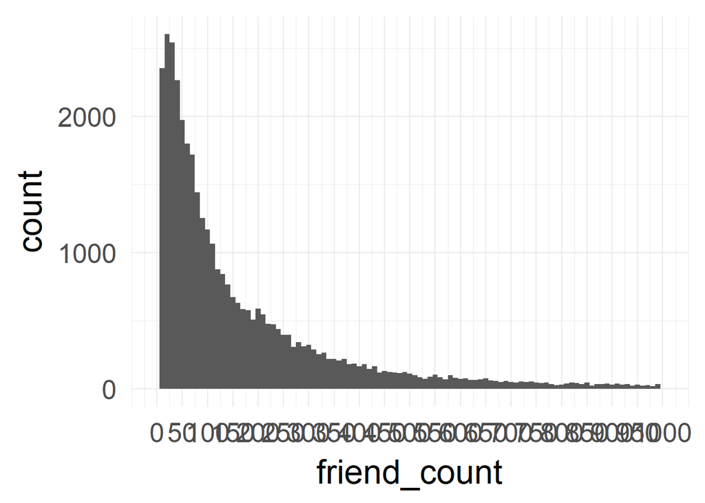

```r
qplot(x = friend_count, data = pf[pf$gender == "female",], binwidth = 10) +
  scale_x_continuous(limits = c(0, 1000),
                     breaks = seq(0, 1000, 50))
```

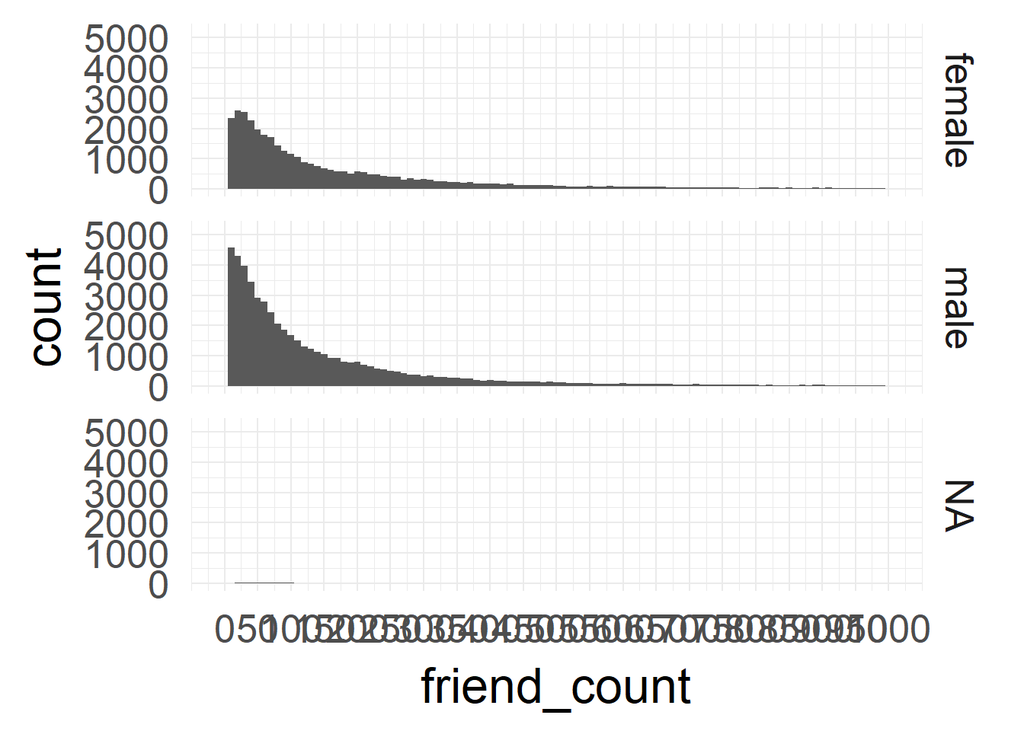

```r
qplot(x = friend_count, data = pf,binwidth = 10) +
  scale_x_continuous(limits = c(0, 1000),
                     breaks = seq(0, 1000, 50)) +
  facet_grid(gender ~ .)
```

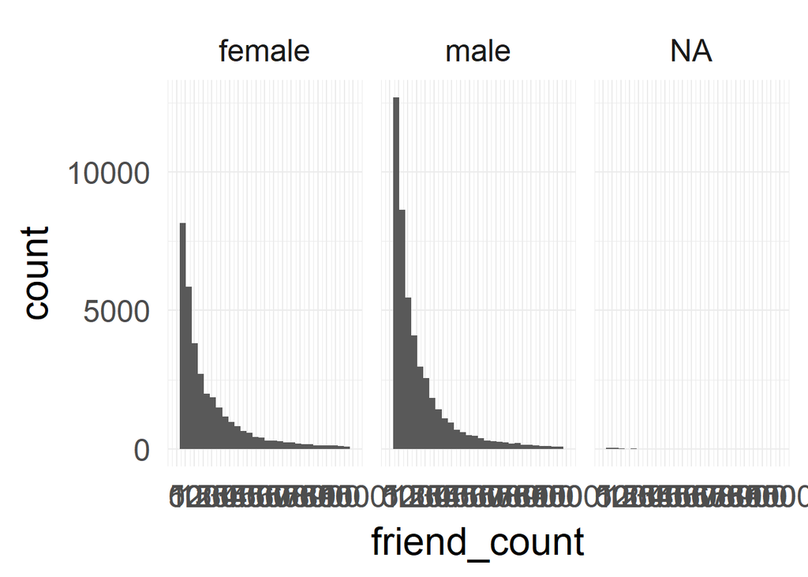

```r
ggplot(aes(x = friend_count), data = pf) +
  geom_histogram() +
  scale_x_continuous(limits = c(0, 1000), breaks = seq(0, 1000, 50)) +
  facet_wrap(~gender)
```

### Omitting NA Values

Notes: Missing values are counted as NA by R.

```r
qplot(x = friend_count, data = subset(pf, !is.na(gender)),binwidth = 10) +
  scale_x_continuous(limits = c(0, 1000),
                     breaks = seq(0, 1000, 50)) +
  facet_wrap(~gender)
# na.omit() would remove any observations that have NA in them
qplot(x = friend_count, data = na.omit(pf),binwidth = 10) +
  scale_x_continuous(limits = c(0, 1000),
                     breaks = seq(0, 1000, 50)) +
  facet_wrap(~gender)
```

[output not shown]

### Statistics ‘by’ Gender

Notes:

```r
table(pf$gender)
```

```
##
## female   male
##  40254  58574
```

```r
by(pf$friend_count, pf$gender, summary)
```

```
## pf$gender: female
##    Min. 1st Qu.  Median    Mean 3rd Qu.    Max.
##       0      37      96     242     244    4923
## --------------------------------------------------------
## pf$gender: male
##    Min. 1st Qu.  Median    Mean 3rd Qu.    Max.
##       0      27      74     165     182    4917
```

#### Who on average has more friends: men or women?

Response: women

#### What’s the difference between the median friend count for women and men?

Response:22

#### Why would the median be a better measure than the mean?

Response:This is a skewed distribution.

### Tenure

Notes:

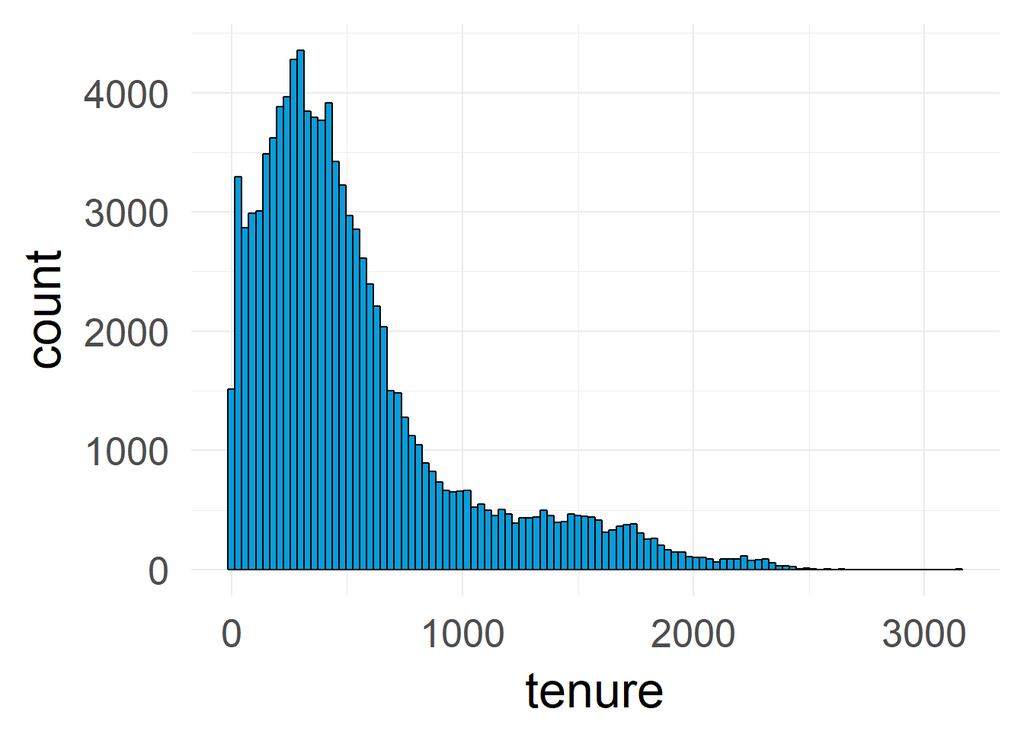

```r
qplot(x = tenure, data = pf, binwidth = 30,
      color = I('black'), fill = I('#099DD9'))
```

#### How would you create a histogram of tenure by year?

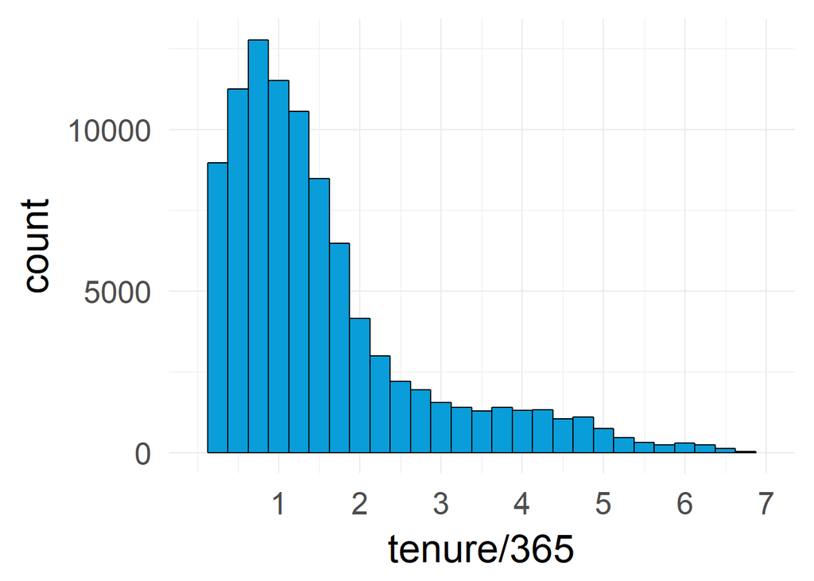

```r
qplot(x = tenure/365, data = pf, binwidth = 0.25,
      color = I('black'), fill = I('#099DD9'))+
  scale_x_continuous(limits = c(0,7), breaks = seq(1,7,1))
```

### Labeling Plots

Notes:

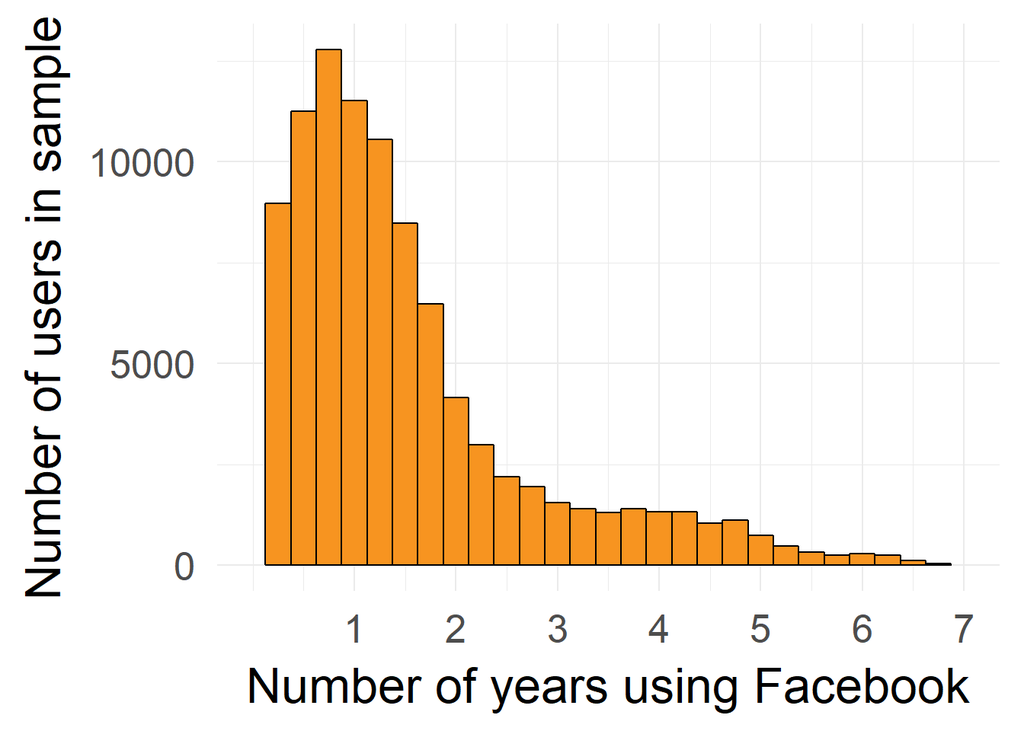

```r
qplot(x = tenure/365, data = pf, binwidth = 0.25,
      xlab = 'Number of years using Facebook',
      ylab = 'Number of users in sample',
      color = I('black'), fill = I('#F79420'))+
  scale_x_continuous(limits = c(0,7), breaks = seq(1,7,1))
```

### User Ages

Notes:

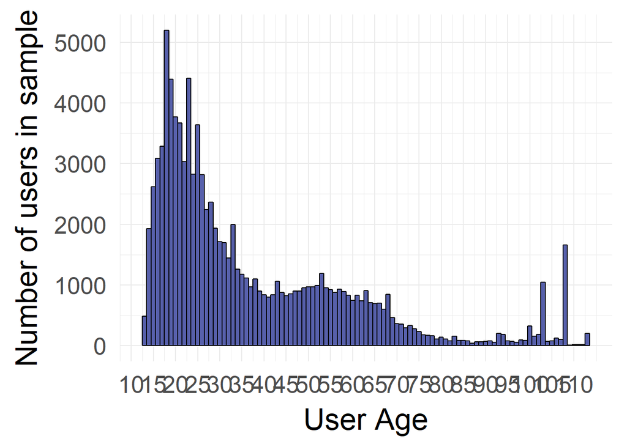

```r
qplot(x = age, data = pf, binwidth = 1,
      xlab = 'User Age',
      ylab = 'Number of users in sample',
      color = I('black'), fill = I('#5760AB')) +
  scale_x_continuous(breaks = seq(0,113,5))
```

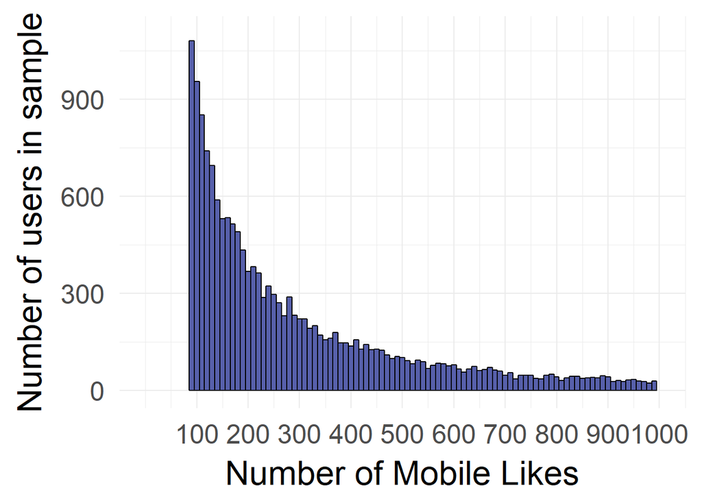

```r
qplot(x = mobile_likes, data = pf,binwidth = 10,
      xlab = 'Number of Mobile Likes',
      ylab = 'Number of users in sample',
      color = I('black'), fill = I('#5760AB')) +
  scale_x_continuous(limits = c(0, 1000), breaks = seq(100,1000,100)) +
  scale_y_continuous(limits = c(0, 1100))
```

### The Spread of Memes

Notes:

### Lada’s Money Bag Meme

Notes: They tended to reoccur sometimes.

### Transforming Data

Notes: engaged values means values that have a long tail. Data is over dispersed.

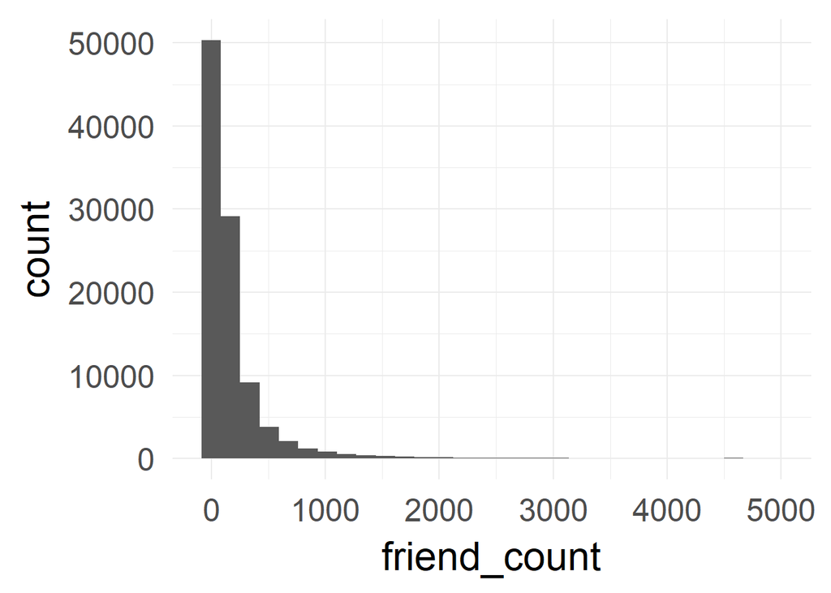

```r
qplot(x=friend_count, data = pf)
```

```r
summary(pf$friend_count)
```

```
##    Min. 1st Qu.  Median    Mean 3rd Qu.    Max.
##     0.0    31.0    82.0   196.4   206.0  4923.0
```

```r
summary(log10(pf$friend_count + 1))
```

```
##    Min. 1st Qu.  Median    Mean 3rd Qu.    Max.
##   0.000   1.505   1.919   1.868   2.316   3.692
```

```r
summary(sqrt(pf$friend_count))
```

```
##    Min. 1st Qu.  Median    Mean 3rd Qu.    Max.
##   0.000   5.568   9.055  11.088  14.353  70.164
```

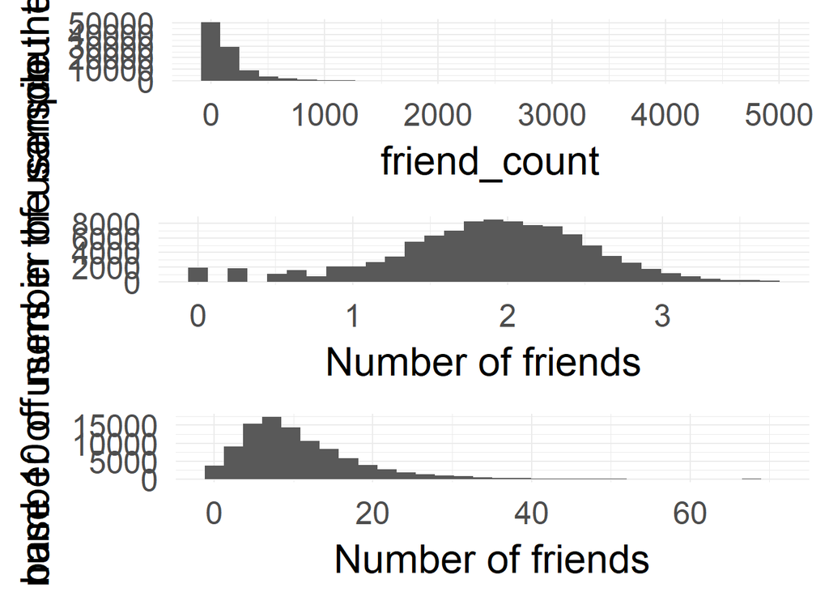

```r
# install.packages('gridExtra')
library(gridExtra)

p1 = qplot(x = friend_count, data = pf)
p2 = qplot(x = log10(friend_count + 1), data = pf,
           xlab = 'Number of friends',
           ylab = 'log base 10 of number of users in the sample')
p3 = qplot(x = sqrt(friend_count), data = pf,
           xlab = 'Number of friends',
           ylab = 'square root of number of users in the sample')
grid.arrange(p1, p2, p3, ncol=1)
```

### Transformating Data Alternate Solution

### Use scales!

Notes:

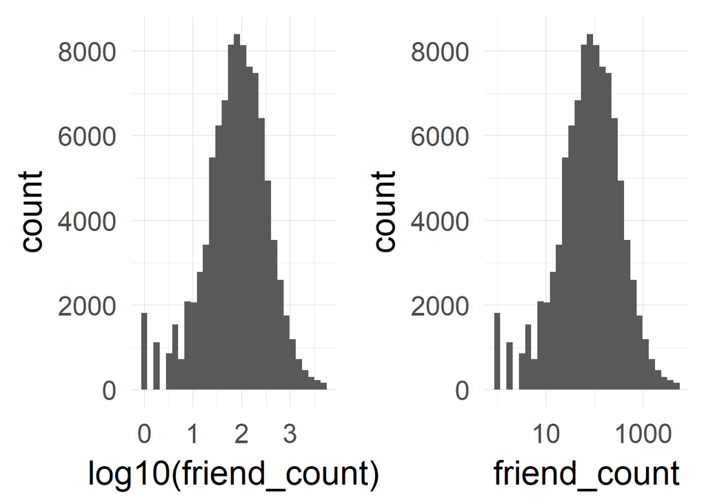

```r
logScale <- qplot(x = log10(friend_count), data = pf)

countScale <- ggplot(aes(x = friend_count), data = pf) +
  geom_histogram() +
  scale_x_log10()

grid.arrange(logScale, countScale, ncol=2)
```

### Add a Scaling Layer

Notes:

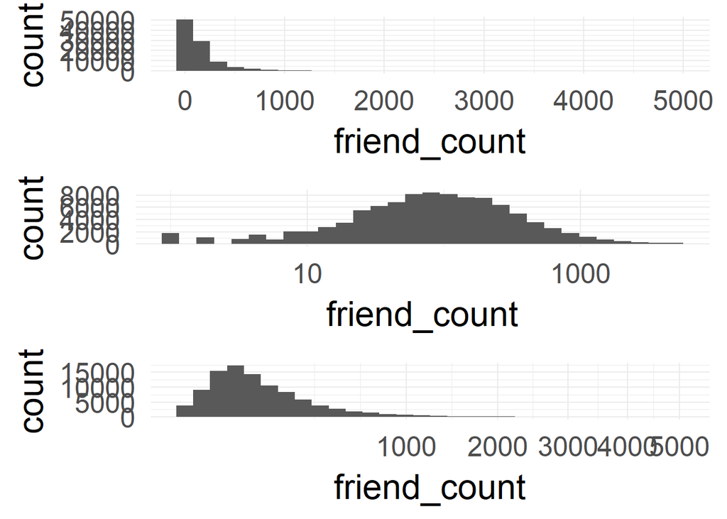

```r
p1 <- ggplot(aes(x = friend_count), data = pf) + geom_histogram()
p2 <- p1 + scale_x_log10()
p3 <- p1 + scale_x_sqrt()

grid.arrange(p1, p2, p3, ncol=1)
```

### Frequency Polygons (before we had histograms, plot two plots on top of each other)

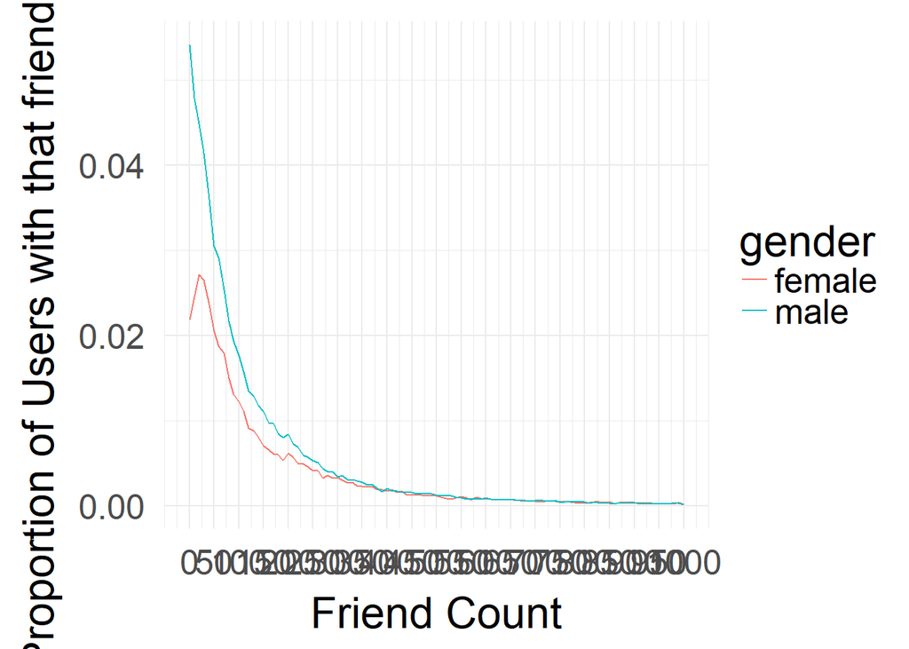

```r
qplot(x = friend_count, data = subset(pf, !is.na(gender)),binwidth = 10) +
  scale_x_continuous(limits = c(0, 1000), breaks = seq(0, 1000, 50)) +
  facet_wrap(~gender)
qplot(x = friend_count, y = ..count../sum(..count..),
        data = subset(pf, !is.na(gender)),
      xlab = 'Friend Count',
      ylab = 'Proportion of Users with that friend count',
      binwidth = 10, geom = 'freqpoly', color = gender) +
  scale_x_continuous(limits = c(0, 1000), breaks = seq(0, 1000, 50))
```

[output not shown]

### Frequency Polygons Solution

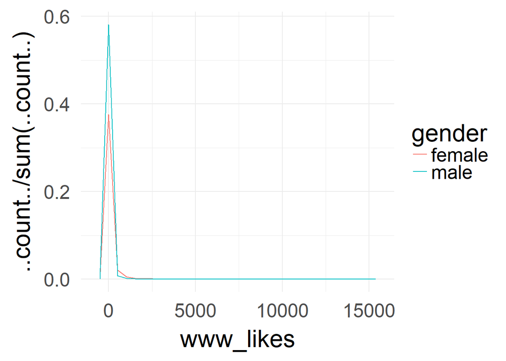

```r
qplot(x = www_likes, y = ..count../sum(..count..), data = subset(pf, !is.na(gender)),
      geom = 'freqpoly', color = gender)
```

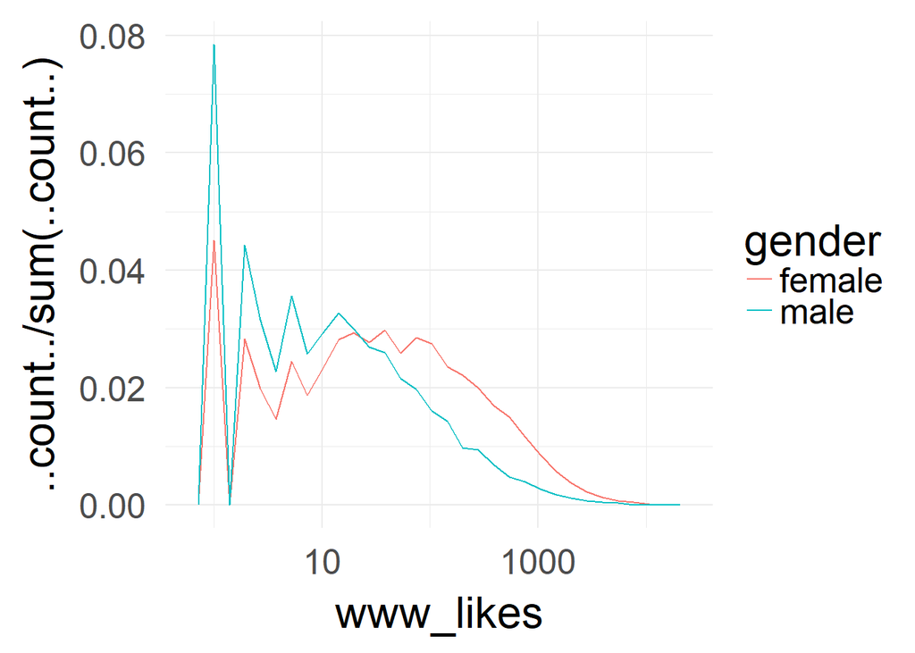

```r
# instructor's solution
qplot(x = www_likes, y = ..count../sum(..count..), data = subset(pf, !is.na(gender)),
      geom = 'freqpoly', color = gender) +
  scale_x_log10()
```

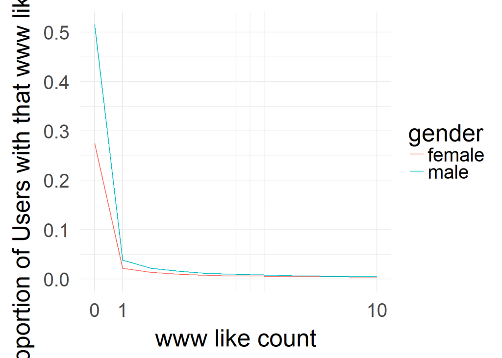

```r
# my solution, not very good
qplot(x = www_likes, y = ..count../sum(..count..), data = subset(pf, !is.na(gender)),
      geom = 'freqpoly', color = gender, binwidth = 1,
      xlab = 'www like count',
      ylab = 'Proportion of Users with that www like count') +
  scale_x_continuous(limits = c(0,10), breaks = c(0,10,1))
```

### Likes on the Web

Notes:

```r
by(pf$www_likes,pf$gender, sum)
```

```
## pf$gender: female
## [1] 3507665
## --------------------------------------------------------
## pf$gender: male
## [1] 1430175
```

### Histograms

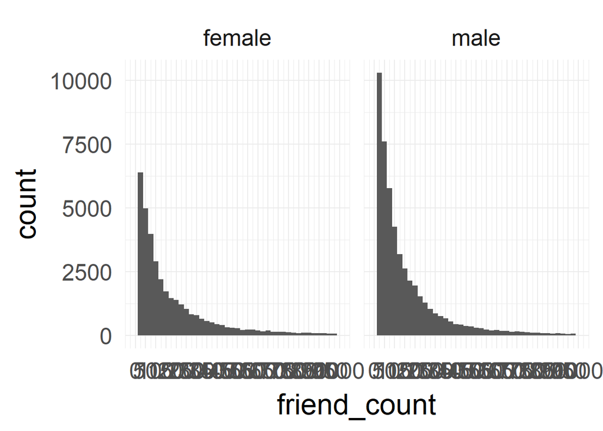

```r
qplot(x = friend_count, data = subset(pf, !is.na(gender)),binwidth = 25) +
  scale_x_continuous(limits = c(0, 1000), breaks = seq(0, 1000, 50)) +
  facet_wrap(~gender)
```

### Box Plots

Notes:

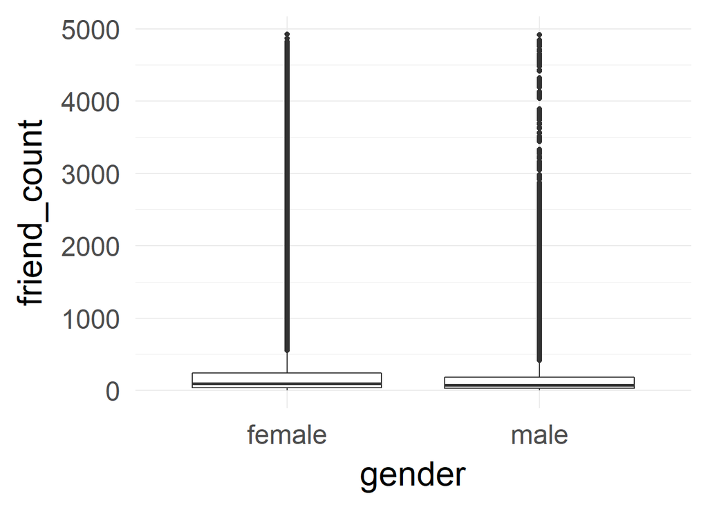

```r
qplot(x = gender, y = friend_count,
      data = subset(pf, !is.na(gender)),
      geom = 'boxplot')
```

#### Adjust the code to focus on users who have friend counts between 0 and 1000.

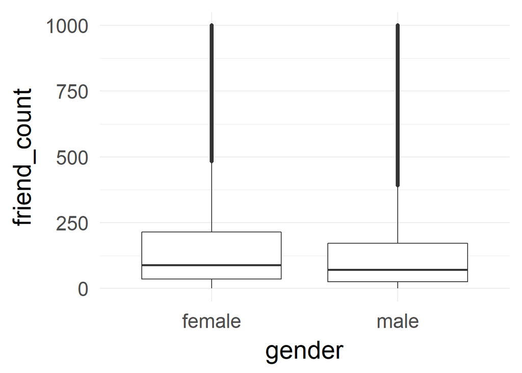

```r
# This way, we removed data from calculation
qplot(x = gender, y = friend_count,
      data = subset(pf, !is.na(gender)),
      geom = 'boxplot') +
  scale_y_continuous(limits = c(0,1000))
```

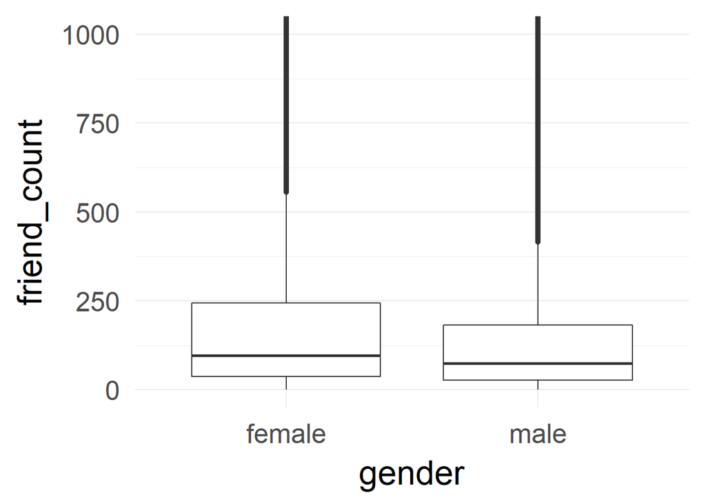

```r
# Using coord_cartesian()
qplot(x = gender, y = friend_count,
      data = subset(pf, !is.na(gender)),
      geom = 'boxplot') +
  coord_cartesian(ylim = c(0, 1000))
```

### Box Plots, Quartiles, and Friendships

Notes:

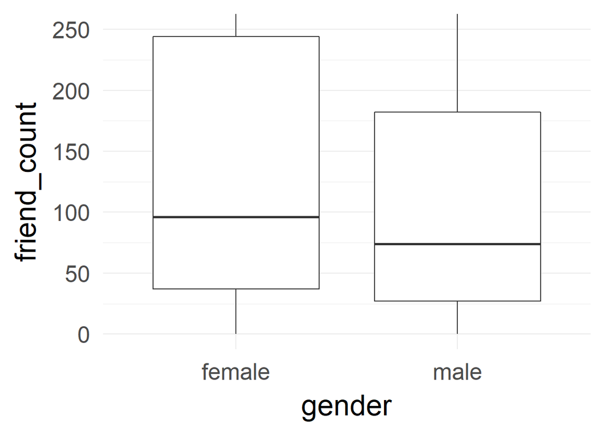

```r
qplot(x = gender, y = friend_count,
      data = subset(pf, !is.na(gender)),
      geom = 'boxplot') +
  coord_cartesian(ylim = c(0, 250))
```

```r
by(pf$friend_count, pf$gender, summary)
```

```
## pf$gender: female
##    Min. 1st Qu.  Median    Mean 3rd Qu.    Max.
##       0      37      96     242     244    4923
## --------------------------------------------------------
## pf$gender: male
##    Min. 1st Qu.  Median    Mean 3rd Qu.    Max.
##       0      27      74     165     182    4917
```

#### On average, who initiated more friendships in our sample: men or women?

```r
names(pf)
```

```
##  [1] "userid"                "age"
##  [3] "dob_day"               "dob_year"
##  [5] "dob_month"             "gender"
##  [7] "tenure"                "friend_count"
##  [9] "friendships_initiated" "likes"
## [11] "likes_received"        "mobile_likes"
## [13] "mobile_likes_received" "www_likes"
## [15] "www_likes_received"
```

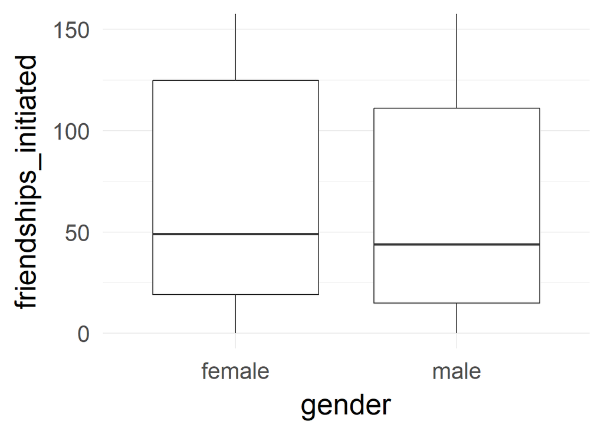

```r
qplot(x = gender, y = friendships_initiated, data = subset(pf,!is.na(gender)), geom = 'boxplot') +
  coord_cartesian(ylim = c(0,150))
```

```r
by(pf$friendships_initiated, pf$gender, summary)
```

```
## pf$gender: female
##    Min. 1st Qu.  Median    Mean 3rd Qu.    Max.
##     0.0    19.0    49.0   113.9   124.8  3654.0
## --------------------------------------------------------
## pf$gender: male
##    Min. 1st Qu.  Median    Mean 3rd Qu.    Max.
##     0.0    15.0    44.0   103.1   111.0  4144.0
```

Response: I used by() function to compare the median number of friends count for different genders, women and men, and then figured out that women make more friends than men on average. ***

### Getting Logical

Notes:

```r
summary(pf$mobile_likes)
```

```
##    Min. 1st Qu.  Median    Mean 3rd Qu.    Max.
##     0.0     0.0     4.0   106.1    46.0 25111.0
```

```r
summary(pf$mobile_likes > 0)
```

```
##    Mode   FALSE    TRUE
## logical   35056   63947
```

```r
pf$mobile_check_in <- NA
pf$mobile_check_in <- ifelse(pf$mobile_check_in > 0, 1, 0)
pf$mobile_check_in <- factor(pf$mobile_check_in)
summary(pf$mobile_check_in)
```

```
##  NA's
## 99003
```

```r
63947/99003
```

```
## [1] 0.6459097
```

```r
sum(pf$mobile_check_in == 1)/length(pf$mobile_check_in)
```

```
## [1] NA
```

Response:

### Analyzing One Variable

Reflection: Understanding the details of one variable. In this lesson, I learnt how to make histogram, boxplot, and frequency polygons for one variable of interest, based on different categories if necessary, to know the basic statistics of the data. I learnt to make some adjustments when analyzing data, in order to exclude the outliers, choose an appropriate data limit, or adjust the bin. ***

Click **KnitHTML** to see all of your hard work and to have an html page of this lesson, your answers, and your notes!